# Change HubSpot Service User Roles

Both client apps, Ordering App and Product Manager, modify what they show and allow a user to do based on HubSpot Service Environmental Variables.

The system has three roles:

- Admin
- Manager
- User

These are assigned to users by the HubSpot Service’s `returnRole` function.

- It first checks the variable **ADMIN_EMAIL** against the current user’s email, and if they match then the user is given the *Admin* role. At present, only one user can be assigned as admin here (as opposed to in HubSpot, or in the Azure subscription).
- If a match is not found, it then checks whether the user’s email is one of the emails in the variable **MANAGER_EMAILS**, and if a match is found then the user is assigned the role *Manager*. There can currently be multiple managers; though the variable is a single string, multiple items are entered in a *comma separated list*.
- If a match has not been found in either variable, then the user is assigned the role *User* by default.

** **If this is a NEW user who has not been assigned a role, and you just want them to be a *User*, you don’t need to do anything.**

Thus in order to change a user’s role, you need to add and/or remove their email from these Environmental Variables. To do this:

## 1. Go to HubSpot Service’s Environmental Variables

- Find `terramax-hubspot-service` in the Azure list of Resources
- Go to Settings > Environmental variables

[figure not shown]

## 2. Edit Variables

- **A.** Make user an *Admin*:
  - If their email is currently in the **MANAGER_EMAILS** variable, remove it. Make sure that the list remains a functional comma-separated string.
  - Replace whatever email is currently in the **ADMIN_EMAIL** variable, and replace it with the user’s email
- **B.** Make user a *Manager*:
  - If their email is currently the **ADMIN_EMAIL** variable, remove it or replace it with a different email. A user can’t be both a *Manager* AND an *Admin*, and the *Admin* role will override the *Manager* one.
  - Add the email to the **MANAGER_EMAILS** variable. Make sure that you format your work correctly so it remains a comma-separated string.
- **C.** Make user a *User*:
  - If their email is currently the **ADMIN_EMAIL** variable, remove it or replace it with a different email.
  - If their email is currently in the **MANAGER_EMAILS** variable, remove it. Make sure that the list remains a functional comma-separated string.

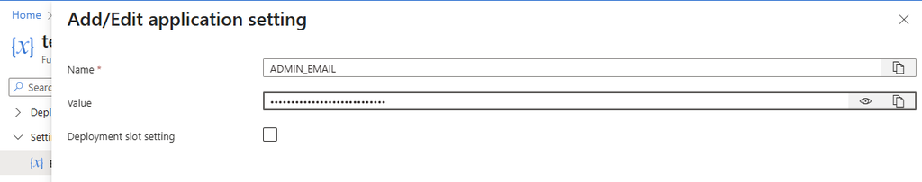

Editing ADMIN_EMAIL

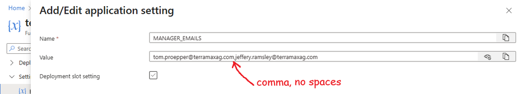

Editing MANAGER_EMAILS